# Tarea 3 - Ejercicios de Correlación

Realizado por Josué Redondo

26-11-2025

## 18. Tamaño de casinos e ingresos.

A continuación se presentan los tamaños (en miles de pies cuadrados) y los ingresos (en millones de dólares) de casinos de Atlantic City (según datos del New York Times). ¿Existe evidencia suficiente para concluir que existe una correlación lineal entre el tamaño de los casinos y sus ingresos?

| Tamaño | 160 | 227 | 140 | 144 | 161 | 147 | 141 |
| --- | --- | --- | --- | --- | --- | --- | --- |
| Ganancias | 189 | 157 | 140 | 127 | 123 | 106 | 101 |

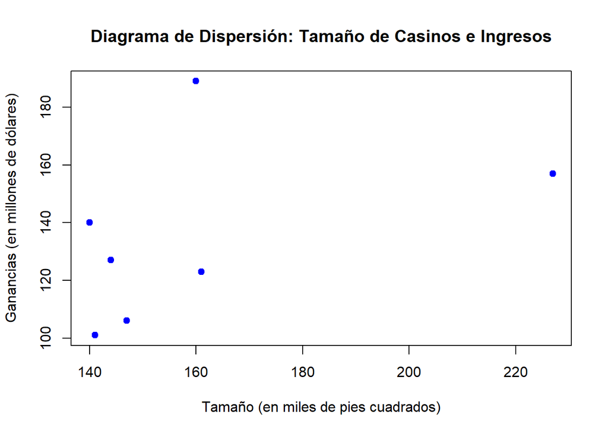

A simple vista, no se visualiza una correlación lineal en el Diagrama de Dispersión.

Al realizar la prueba de correlación usando el comando “cor.test()” cargado con los vectores que contienen los datos numéricos, obtenemos como resultado que $r = 0,4456$ y $p = 0,3176$, lo cual demuestra que es una correlación positiva moderada. No obstante, debido a que el valor de $p$ es mayor a $0,05$, no es estadísticamente significativo.

Por lo tanto, no existe evidencia suficiente para concluir que existe una correlación lineal entre el tamaño de un casino y la cantidad de ingresos que tiene.

## 19. Tarifas aéreas.

A continuación se presentan los precios (en dólares) de tarifas aéreas de diferentes aerolíneas desde la ciudad de Nueva York (JFK) a San Francisco. Los precios se basan en boletos comprados con 30 días de anticipación y un día de anticipación; las aerolíneas son US Air, Continental, Delta, United, American, Alaska y Northwest. ¿Hay evidencia suficiente para concluir que existe una correlación lineal entre los precios de los boletos comprados con 30 días de anticipación y los boletos comprados con un día de anticipación?

| Treinta_días | 244 | 260 | 264 | 264 | 278 | 318 | 280 |
| --- | --- | --- | --- | --- | --- | --- | --- |
| Un_día | 456 | 614 | 567 | 943 | 628 | 1088 | 536 |

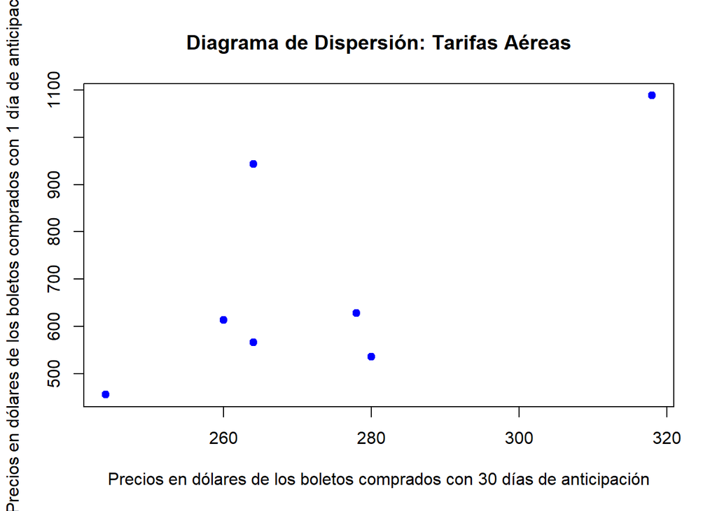

A simple vista, no se visualiza una correlación lineal en el Diagrama de Dispersión.

Al realizar la prueba de correlación usando el comando “cor.test()” cargado con los vectores que contienen los datos numéricos, obtenemos como resultado que $r = 0,7088$ y $p = 0,0746$, lo cual demuestra que es una correlación positiva fuerte. No obstante, debido a que el valor de $p$ es mayor a $0,05$ no es estadísticamente significativo.

No existe evidencia suficiente para concluir que existe una correlación lineal entre los precios de los boletos comprados com 30 días de anticipación y los boletos comprados con un día de anticipación.

## 20. Pasajeros y espacios de estacionamiento.

A continuación se presentan los números de pasajeros y los números de espacios de estacionamiento en diferentes estaciones del tren Metro-North (según datos de Metro- North). ¿Existe una correlación lineal entre los números de pasajeros y los números de espacios de estacionamiento?

| Pasajeros | 3453 | 1350 | 1126 | 3120 | 2641 | 277 | 579 | 2532 |
| --- | --- | --- | --- | --- | --- | --- | --- | --- |
| Espacios_de_Estacionamiento | 1653 | 676 | 294 | 950 | 1216 | 179 | 466 | 1454 |

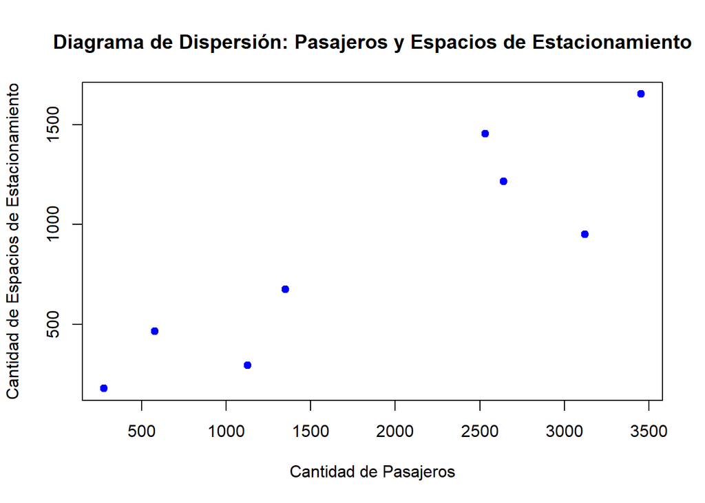

A simple vista, tiene la apariencia de que sigue un patrón lineal.

Al realizar la prueba de correlación usando el comando “cor.test()” cargado con los vectores que contienen los datos numéricos, obtenemos como resultado que $r = 0,9012$ y $p = 0,0022$, lo cual demuestra que es una correlación positiva muy fuerte. Debido a que el valor de $p$ es menor a $0,5$ si es estadísticamente significativo.

Por lo tanto, existe evidencia suficiente para concluir que si existe una correlación lineal entre la cantidad de pasajeros y los números de espacios de estacionamiento de las diferentes estaciones del tren Metro-North.

## 21. Costos de reparación de automóviles.

A continuación se presentan los costos de reparación (en dólares) para automóviles que participaron en pruebas de choques frontales a una velocidad de 6 mi/h y en pruebas de choques traseros a una velocidad de 6 mi/h (según datos del Insurance Institute for Highway Safety). Los automóviles son Toyota Camry, Mazda 6, Volvo S40, Saturn Aura, Subaru Legacy, Hyundai Sonata y Honda Accord. ¿Hay evidencia suficiente para concluir que existe una correlación lineal entre los costos de reparación de los choques frontales y de los choques traseros?

| Choques_Frontales | 936 | 978 | 2252 | 1032 | 3911 | 4312 | 3469 |
| --- | --- | --- | --- | --- | --- | --- | --- |
| Choques_Traseros | 1480 | 1202 | 802 | 3191 | 1122 | 739 | 2767 |

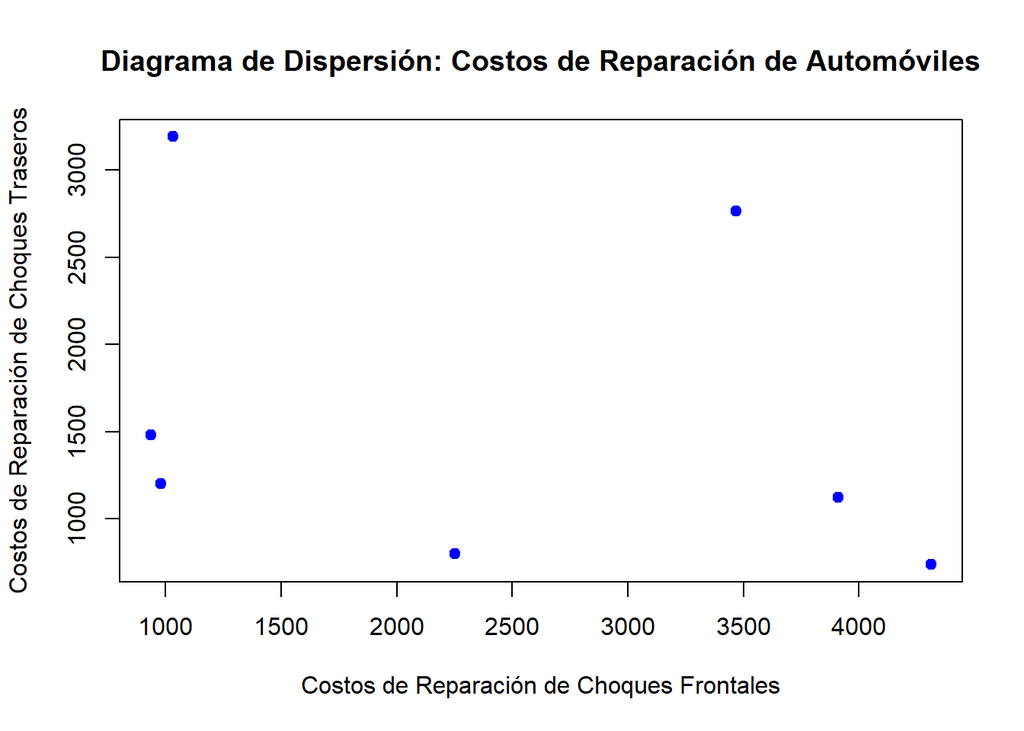

A simple vista, no se visualiza una correlación lineal en el Diagrama de Dispersión.

No existe evidencia suficiente para concluir que existe una correlación lineal entre los costos de reparación por choques frontales y los costos de reparación por choques traseros.